# Assignment 3, Task 4

Alessandra Puig-Santana

10/28/2021

# Overview

This code wrangles and visualizes the purple urchin population in Naples Reef in Santa Barbara, CA collected by Santa Barbara Coastal Long Term Ecological Research program divers. We practiced creating a descriptive statistics table comparing the treatments used on purple urchin populations.

##### Citation:

Reed, D. 2020. SBC LTER: Reef: Long-term experiment: Kelp removal: Urchin size frequency distribution ver 20. Environmental Data Initiative. https://doi.org/10.6073/pasta/5a1e9ef03aa47bd2225c0bb98a02a63b.

### Set up chunk

```r
knitr::opts_chunk$set(echo = TRUE, warning = FALSE, message = FALSE)
# Setting up packages
library(tidyverse)
library(here)
library(janitor)
library(lubridate)
library(kableExtra)
```

### Read in data

```r
# Read in data and convert to lower_case_snake
urchins <- read_csv(here("data", "urchins.csv")) %>%
  clean_names
```

## Data Wrangling

Created a subset data frame that only contains the observations in 2010 for the Purple Urchin population in the Naples Reef.

```r
purple_naples <- urchins %>%
  filter(common_name == "Purple Urchin") %>% # Only selecting purple urchin
  filter(site == "NAPL") %>% # Only selecting Naples Reef
  mutate(date = mdy(date)) %>%
  mutate(year = year(date)) %>% # Creating new year column
  filter(year == 2010) %>% # Only selecting 2010.
  mutate(treatment = case_when(treatment == "ANNUAL" ~ "Experimental", # Annual Kelp removal
                               treatment == "CONTROL" ~ "Control")) # No kelp removal
```

## Data Visualization

### Figure 1: Histogram

Faceted histogram size distribution of purple urchins at Naples in 2010, separated by treatment (Control and Annual), to assess normality.

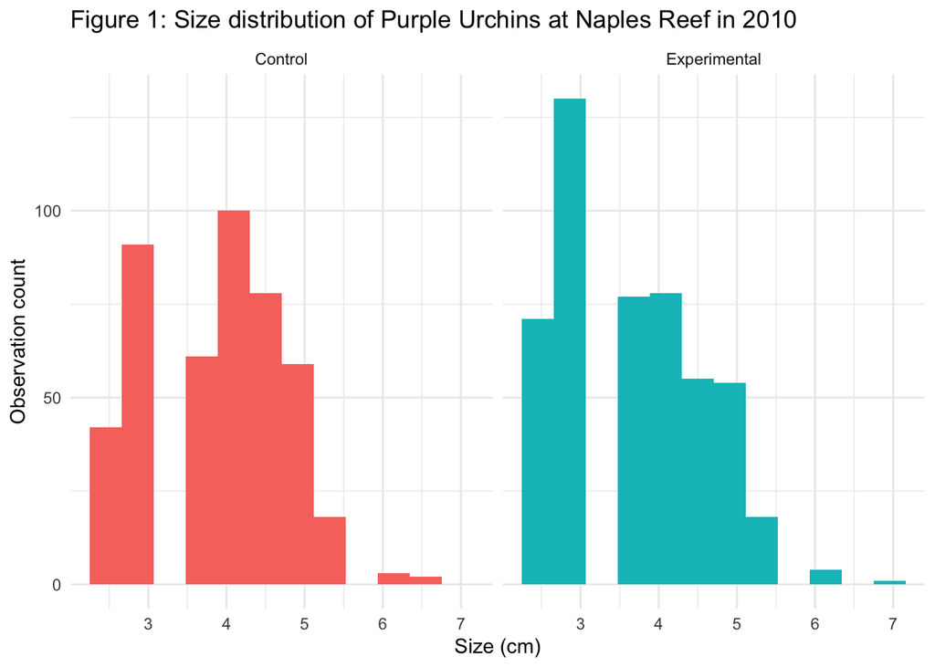

```r
ggplot(data = purple_naples, aes(x = size)) +
  geom_histogram(bins = 12,
                 aes(fill = treatment),
                 show.legend = FALSE) + # Not showing legend
  facet_wrap(~treatment) + # Separated by treatment
  labs(title = "Figure 1: Size distribution of Purple Urchins at Naples Reef in 2010",
       y = "Observation count",
       x = "Size (cm)") +
  theme_minimal()
```

### Figure 2: QQ-Plot

QQ-plots for the size distribution of purple urchins at Naples in 2010, separated by treatment (Control and Annual), to assess normality.

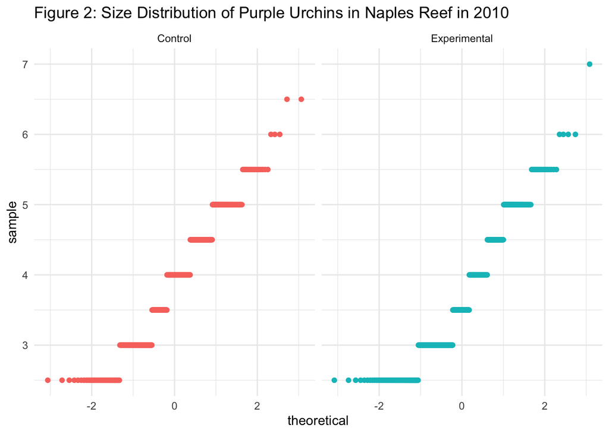

```r
ggplot(data = purple_naples, aes(sample = size,
                                 color = treatment)) +
  geom_qq(show.legend = FALSE) + # Don't show legend
  facet_wrap(~treatment) + # Divide by treatment
  theme_minimal() +
  labs(title = "Figure 2: Size Distribution of Purple Urchins in Naples Reef in 2010")
```

## Summary Statistics

A finalized summary table of descriptive statistics (mean, standard deviation, and sample size) for both groups by treatment.

```r
purple_urchins_stats <- purple_naples %>%
  group_by(treatment) %>% # Grouping by treatment
  summarize(mean_size = round(mean(size), 2), # Calculating mean
            sd_size = round(sd(size), 2), # Calculating standard deviation
            sample_size = n()) # Calculating sample size

purple_urchins_stats %>% # Renaming column names
  kable(col.names = c("Species", # Keep same order as calculated in summarize() function
                      "Mean Size (cm)",
                      "Standard Deviation (cm)",
                      "Sample Size"),
        caption = "Table 1: This table contains the summary statistics comparing mean (cm), standard deviation (cm), and sample for Purple Urchins in Naples Reef in 2010 for the control and experimental treatments.")
```

Table 1: This table contains the summary statistics comparing mean (cm), standard deviation (cm), and sample for Purple Urchins in Naples Reef in 2010 for the control and experimental treatments.

| Species | Mean Size (cm) | Standard Deviation (cm) | Sample Size |
| --- | --- | --- | --- |
| Control | 3.89 | 0.87 | 454 |
| Experimental | 3.68 | 0.90 | 488 |